# bartcs: An R Package for Bayesian Nonparametric Adjustment for Confounding

#### Scenario C: 5 true confounders and 2 instrumental variables

This scenario includes 5 true confounders among 100 potential confounders, and in particular, it includes 2 instrumental variables (i.e., variables that affect only the exposure). The data generating process for this scenario is as follows:

```r
set.seed(42)
N <- 300
P <- 100
cov <- list()
for (i in seq_len(P)) {
  cov[[i]] <- rnorm(N, 0, 1)
}
X <- do.call(cbind, cov)
h1 <- ifelse(X[, 1] < 0, 1, -1)
h2 <- ifelse(X[, 2] < 0, -1, 1)
prob <- pnorm(0.5 + h1 + h2 - 0.5 * abs(X[, 3] - 1) +
                1.5 * X[, 4] * X[, 5] + 1.5 * X[, 6] - 1 * X[, 7])
Trt <- rbinom(N, 1, prob)
mu1 <- 1 * h1 + 1.5 * h2 - 1 + 2 * abs(X[, 3] + 1) +
  2 * X[, 4] + exp(0.5 * X[, 5])
mu0 <- 1 * h1 + 1.5 * h2 - 0 + 2 * abs(X[, 3] + 1) +
  2 * X[, 4] + exp(0.5 * X[, 5])
Y1 <- rnorm(N, mu1, 0.3)
Y0 <- rnorm(N, mu0, 0.3)
Y <- Trt * Y1 + (1 - Trt) * Y0
```

When the separate model is fitted, the 95% credible intervals successfully capture the true values of SATE, E[Y(1)], and E[Y(0)], which are -0.98, 2.21, and 3.19, respectively. Similarly, the single model also provides accurate estimates of the true values.

```r
separate_fit <- separate_bart(
     Y = Y, trt = Trt, X = X, num_tree = 200, num_chain = 4,
     num_burn_in = 10000, num_thin = 5, num_post_sample = 2000
)

separate_fit
`bartcs` fit by `separate_bart()`

          mean      2.5%     97.5%
SATE -0.905955 -1.172369 -0.634617
Y1    2.173088  1.976194  2.375582
Y0    3.079043  2.898203  3.261354
```

```r
single_fit <- single_bart(
     Y = Y, trt = Trt, X = X, num_tree = 200, num_chain = 4,
     num_burn_in = 10000, num_thin = 5, num_post_sample = 2000
)

single_fit
`bartcs` fit by `single_bart()`

           mean      2.5%      97.5%
SATE -0.9421112 -1.116511 -0.7714885
Y1    2.1999294  2.089350  2.3124345
Y0    3.1420407  3.040003  3.2451105
```

To assess confounder selection performance, 500 simulated datasets were generated based on the data-generating process described above, including 5 true confounders and 2 instrumental variables. Figure 14 shows the average posterior inclusion probabilities obtained across these datasets, comparing results from the separate model (top panel) and the single model (bottom panel). The results clearly demonstrate that all 5 true confounders (marked with red circles) are consistently selected with posterior probabilities equal to one, whereas irrelevant noise variables are effectively excluded from the models.

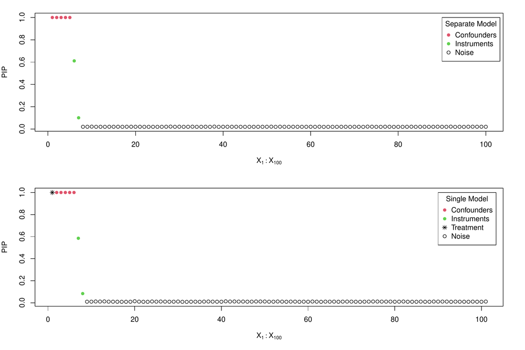

Figure 14: Average PIPs across 500 simulated datasets based on the scenario containing 5 true confounders and 2 instrumental variables, comparing the separate and single models. Red circles indicate the true confounders, green circles represent the instrumental variables, and empty circles denote noise variables. In the single model, the first starred point represents the treatment variable.

### 9 Supplementary materials

Supplementary materials are available in addition to this article. It can be downloaded at RJ-2025-019.zip

### 10 Note

This article is converted from a Legacy LaTeX article using the texor package. The pdf version is the official version. To report a problem with the html, refer to CONTRIBUTE on the R Journal homepage.

A. Abadie. Semiparametric difference-in-differences estimators. *The Review of Economic Studies*, 72(1): 1–19, 2005.

J. H. Albert and S. Chib. Bayesian analysis of binary and polychotomous response data. *Journal of the American Statistical Association*, 88(422): 669–679, 1993.

M. M. Barbieri and J. O. Berger. Optimal predictive model selection. *The Annals of Statistics*, 32(3): 870–897, 2004.

A. Caron, G. Baio and I. Manolopoulou. Shrinkage bayesian causal forests for heterogeneous treatment effects estimation. *Journal of Computational and Graphical Statistics*, 31(4): 1202–1214, 2022.

H. A. Chipman, E. I. George, R. E. McCulloch, et al. BART: Bayesian additive regression trees. *The Annals of Applied Statistics*, 4(1): 266–298, 2010.

P. Ding and F. Li. Causal inference. *Statistical Science*, 33(2): 214–237, 2018.

P. Ding, T. VanderWeele and J. M. Robins. Instrumental variables as bias amplifiers with general outcome and confounding. *Biometrika*, 104(2): 291–302, 2017.

V. Dorie. *NPCI: Non-parametrics for causal inference.* 2016. URL https://github.com/vdorie/npci.

J. Häggström. *CovSelHigh: Model-free covariate selection in high dimensions.* 2017. URL https://CRAN.R-project.org/package=CovSelHigh. R package version 1.1.1.

J. Häggström. Data-driven confounder selection via Markov and Bayesian networks. *Biometrics*, 74(2): 389–398, 2018.

P. R. Hahn, J. S. Murray and C. M. Carvalho. Bayesian regression tree models for causal inference: Regularization, confounding, and heterogeneous effects. *Bayesian Analysis*, 15(3): 965–1056, 2020. DOI 10.1214/19-BA1195.

T. Hastie and R. Tibshirani. Bayesian backfitting (with comments and a rejoinder by the authors). *Statistical Science*, 15(3): 196–223, 2000.

J. L. Hill. Bayesian nonparametric modeling for causal inference. *Journal of Computational and Graphical Statistics*, 20(1): 217–240, 2011. DOI 10.1198/jcgs.2010.08162.

A. Kapelner and J. Bleich. BartMachine: Machine learning with Bayesian additive regression trees. *Journal of Statistical Software*, 70(4): 1–40, 2016. DOI 10.18637/jss.v070.i04.

C. Kim, M. Tec and C. M. Zigler. Bayesian nonparametric adjustment of confounding. *Biometrics*, 79(4): 3252–3265, 2023. DOI 10.1111/biom.13833.

G. Lefebvre, J. A. Delaney and R. L. McClelland. Extending the Bayesian adjustment for confounding algorithm to binary treatment covariates to estimate the effect of smoking on carotid intima-media thickness: The multi-ethnic study of atherosclerosis. *Statistics in Medicine*, 33(16): 2797–2813, 2014.

F. Li, P. Ding and F. Mealli. Bayesian causal inference: A critical review. *Philosophical Transactions of the Royal Society A*, 381(2247): 20220153, 2023.

A. R. Linero. Bayesian regression trees for high-dimensional prediction and variable selection. *Journal of the American Statistical Association*, 113(522): 626–636, 2018.

C. Louizos, U. Shalit, J. M. Mooij, D. Sontag, R. Zemel and M. Welling. Causal effect inference with deep latent-variable models. *Advances in Neural Information Processing Systems*, 30: 2017. URL https://github.com/AMLab-Amsterdam/CEVAE.

J. S. Murray. Log-linear Bayesian additive regression trees for multinomial logistic and count regression models. *Journal of the American Statistical Association*, 116(534): 756–769, 2021.

J. A. Myers, J. A. Rassen, J. J. Gagne, K. F. Huybrechts, S. Schneeweiss, K. J. Rothman, M. M. Joffe and R. J. Glynn. Effects of adjusting for instrumental variables on bias and precision of effect estimates. *American Journal of Epidemiology*, 174(11): 1213–1222, 2011.

T. Neitmann, J. Silge and D. Robinson. *Ggcharts: Shorten the distance from data visualization idea to actual plot.* 2020. URL https://CRAN.R-project.org/package=ggcharts. R package version 0.2.1.

A. Oganisian and J. A. Roy. Invited discussion for Bayesian regression tree models for causal inference: Regularization, confounding, and heterogeneous effects. *Bayesian Analysis*, 15(3): 998–1006, 2020.

G. Papadogeorgou and F. Li. Invited discussion for Bayesian regression tree models for causal inference: Regularization, confounding, and heterogeneous effects. *Bayesian Analysis*, 15(3): 1007–1013, 2020.

M. Plummer, N. Best, K. Cowles and K. Vines. CODA: Convergence diagnosis and output analysis for MCMC. *R News*, 6(1): 7–11, 2006. URL https://journal.r-project.org/archive/.

M. Plummer, N. Best, K. Cowles, K. Vines, D. Sarkar, D. Bates, R. Almond and A. Magnusson. *Coda: Output analysis and diagnostics for MCMC.* 2020. URL https://CRAN.R-project.org/package=coda. R package version 0.19-4.

M. T. Pratola. Efficient metropolis–hastings proposal mechanisms for Bayesian regression tree models. *Bayesian Analysis*, 11(3): 885–911, 2016.

P. R. Rosenbaum and D. B. Rubin. The central role of the propensity score in observational studies for causal effects. *Biometrika*, 70(1): 41–55, 1983.

D. B. Rubin. Discussion of randomization analysis of experimental data: The Fisher randomization test by D. Basu. *Journal of the American Statistical Association*, 75(371): 591–593, 1980.

D. B. Rubin. Estimating causal effects of treatments in randomized and nonrandomized studies. *Journal of Educational Psychology*, 66(5): 688, 1974.

S. M. Shortreed and A. Ertefaie. Outcome-adaptive lasso: Variable selection for causal inference. *Biometrics*, 73(4): 1111–1122, 2017.

R. A. Sparapani, B. R. Logan, R. E. McCulloch and P. W. Laud. Nonparametric survival analysis using Bayesian additive regression trees (BART). *Statistics in Medicine*, 35(16): 2741–2753, 2016.

R. Sparapani, C. Spanbauer and R. McCulloch. Nonparametric machine learning and efficient computation with Bayesian additive regression trees: The BART R package. *Journal of Statistical Software*, 97(1): 1–66, 2021. DOI 10.18637/jss.v097.i01.

T. J. VanderWeele. Principles of confounder selection. *European Journal of Epidemiology*, 34(3): 211–219, 2019.

A. Vehtari, A. Gelman, D. Simpson, B. Carpenter and P.-C. Bürkner. Rank-normalization, folding, and localization: An improved R-hat for assessing convergence of MCMC (with discussion). *Bayesian Analysis*, 16(2): 667–718, 2021.

C. Wang, F. Dominici, G. Parmigiani and C. M. Zigler. Accounting for uncertainty in confounder and effect modifier selection when estimating average causal effects in generalized linear models. *Biometrics*, 71(3): 654–665, 2015.

C. Wang, G. Parmigiani and F. Dominici. Bayesian effect estimation accounting for adjustment uncertainty. *Biometrics*, 68(3): 661–671, 2012.

A. Wilson, H. D. Bondell and B. J. Reich. *BayesPen: Bayesian penalized credible regions.* 2015. URL https://anderwilson.github.io/BayesPen. R package version 1.2.

A. Wilson and B. J. Reich. Confounder selection via penalized credible regions. *Biometrics*, 70(4): 852–861, 2014.

Y. Yoo. *Bartcs: Bayesian additive regression trees for confounder selection.* 2024. URL https://CRAN.R-project.org/package=bartcs. R package version 1.2.2.

K. Yoshida and A. Bartel. *Tableone: Create “table 1” to describe baseline characteristics with or without propensity score weights.* 2022. URL https://CRAN.R-project.org/package=tableone. R package version 0.13.2.